# Mini_Project_ML1_Task2_3_60009210068

[figure not shown]

## Problem Statement

This dataset contains information on the insurance claim. Each observation is different policyholder with various features like the age of the person, the gender of the policyholder, body mass index, providing an understanding of the body, number of children of the policyholder, smoking state of the policyholder and individual medical costs billed by health insurance.

```
  Feature                                      Description

    age                                   age of policyholder

    sex                                   male(1)/female(0)

    bmi                                   body mass index(kg / m2)

    children                              number of children/dependents of policyholder

    smoker                                smoking state nonsmoker(0)/smoker(1)

    region                                residential area northeast(0)/northwest(1)/southeast(2)/southwest(3)

    charges                               medical cost

    insuranceclaim                        yes(1)/no(0)
```

Using Proper model try to predict the insurance claim

```python
#Importing Libraries
import pandas as pd
import numpy as np
import matplotlib.pyplot as plt
import seaborn as sns
```

```python
#load Dataset
df=pd.read_csv("insurance3r2.csv")
```

```python
df
```

|  | age | sex | bmi | steps | children | smoker | region | charges | insuranceclaim |
| --- | --- | --- | --- | --- | --- | --- | --- | --- | --- |
| 0 | 19 | 0 | 27.90 | 3009 | 0 | 1 | 3 | 16884.92 | 1 |
| 1 | 18 | 1 | 33.77 | 3008 | 1 | 0 | 2 | 1725.55 | 1 |
| 2 | 28 | 1 | 33.00 | 3009 | 3 | 0 | 2 | 4449.46 | 0 |
| 3 | 33 | 1 | 22.70 | 10009 | 0 | 0 | 1 | 21984.47 | 0 |
| 4 | 32 | 1 | 28.88 | 8010 | 0 | 0 | 1 | 3866.86 | 1 |
| ... | ... | ... | ... | ... | ... | ... | ... | ... | ... |
| 1333 | 50 | 1 | 30.97 | 4008 | 3 | 0 | 1 | 10600.55 | 0 |
| 1334 | 18 | 0 | 31.92 | 3003 | 0 | 0 | 0 | 2205.98 | 1 |
| 1335 | 18 | 0 | 36.85 | 3008 | 0 | 0 | 2 | 1629.83 | 1 |
| 1336 | 21 | 0 | 25.80 | 8009 | 0 | 0 | 3 | 2007.94 | 0 |
| 1337 | 61 | 0 | 29.07 | 8008 | 0 | 1 | 1 | 29141.36 | 1 |

1338 rows × 9 columns

```python
df.shape
```

```
(1338, 9)
```

```python
df.size
```

```
12042
```

```python
df.info()
```

```
<class 'pandas.core.frame.DataFrame'>
RangeIndex: 1338 entries, 0 to 1337
Data columns (total 9 columns):
 #   Column          Non-Null Count  Dtype
---  ------          --------------  -----
 0   age             1338 non-null   int64
 1   sex             1338 non-null   int64
 2   bmi             1338 non-null   float64
 3   steps           1338 non-null   int64
 4   children        1338 non-null   int64
 5   smoker          1338 non-null   int64
 6   region          1338 non-null   int64
 7   charges         1338 non-null   float64
 8   insuranceclaim  1338 non-null   int64
dtypes: float64(2), int64(7)
memory usage: 94.2 KB
```

```python
#checking for null values
df.isnull().sum()
```

```
age               0
sex               0
bmi               0
steps             0
children          0
smoker            0
region            0
charges           0
insuranceclaim    0
dtype: int64
```

```python
#describe for numeric features
df.describe()
```

|  | age | sex | bmi | steps | children | smoker | region | charges | insuranceclaim |
| --- | --- | --- | --- | --- | --- | --- | --- | --- | --- |
| count | 1338.00 | 1338.00 | 1338.00 | 1338.00 | 1338.00 | 1338.00 | 1338.00 | 1338.00 | 1338.00 |
| mean | 39.21 | 0.51 | 30.66 | 5328.62 | 1.09 | 0.20 | 1.52 | 13270.42 | 0.59 |
| std | 14.05 | 0.50 | 6.10 | 2453.64 | 1.21 | 0.40 | 1.10 | 12110.01 | 0.49 |
| min | 18.00 | 0.00 | 15.96 | 3000.00 | 0.00 | 0.00 | 0.00 | 1121.87 | 0.00 |
| 25% | 27.00 | 0.00 | 26.30 | 3008.00 | 0.00 | 0.00 | 1.00 | 4740.29 | 0.00 |
| 50% | 39.00 | 1.00 | 30.40 | 4007.00 | 1.00 | 0.00 | 2.00 | 9382.03 | 1.00 |
| 75% | 51.00 | 1.00 | 34.69 | 8004.00 | 2.00 | 0.00 | 2.00 | 16639.91 | 1.00 |
| max | 64.00 | 1.00 | 53.13 | 10010.00 | 5.00 | 1.00 | 3.00 | 63770.43 | 1.00 |

#### Observations:

1.There are no Categoric features in our data.

2.There are no null values in our datset.

3.Minimum age of policyholder is 18 i.e only legal age barrier people have optioned for policy.

4.Maximum age of policyholder is 64.

5.Mostly people have 1 or 2 childrens but there is some sort of outliers we can say where maximum childens are 5.

6.Minumum charges for policy is 1121 and maximum is 63770.

## EDA : Exploratory Data Analysis

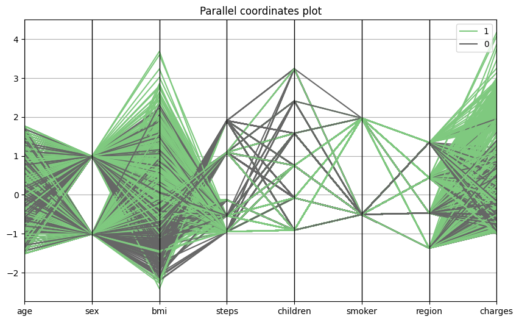

```python
from pandas.plotting import parallel_coordinates

df_norm = (df - df.mean()) / df.std()
df_norm['insuranceclaim'] = df['insuranceclaim']
plt.figure(figsize=(10, 6))
parallel_coordinates(df_norm, 'insuranceclaim', colormap='Accent')
plt.xticks()
plt.title('Parallel coordinates plot')
plt.show()
```

##### Following is the information from Wikipedia, now lets understand this in our data

```
Underweight: BMI less than 18.5
Normal weight: BMI between 18.5 and 24.9
Overweight: BMI between 25 and 29.9
Obese: BMI 30 or higher
```

Distribution of BMI values

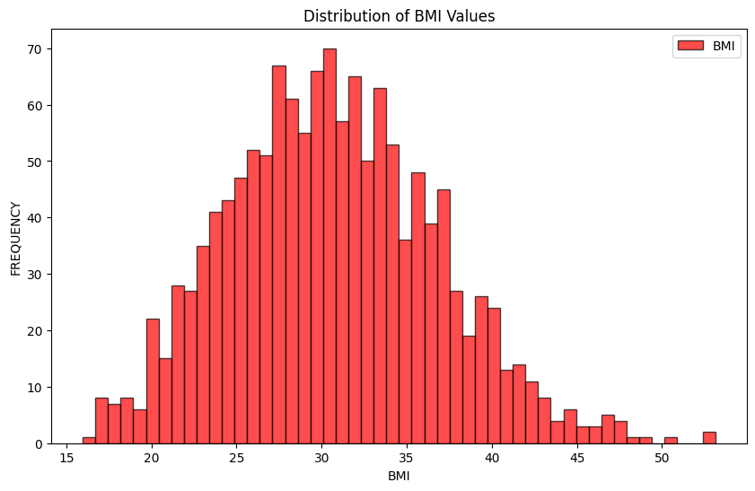

```python
plt.figure(figsize=(10,6))
plt.hist(df["bmi"],bins=50,color="red",histtype="bar",label="BMI",edgecolor="Black",alpha=0.7)
plt.xlabel("BMI")
plt.ylabel("FREQUENCY")
plt.title('Distribution of BMI Values')
plt.legend()
plt.show()
```

BMI v/s Age

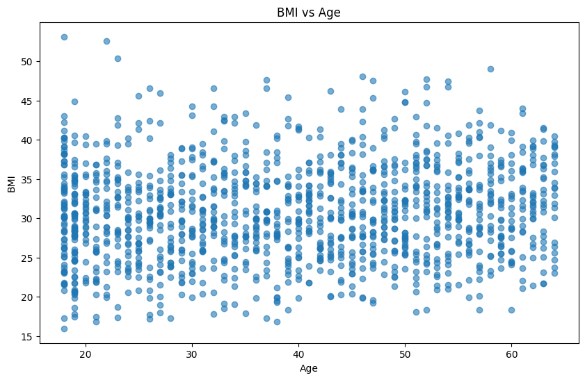

```python
plt.figure(figsize=(10,6))
plt.scatter(df["age"],df["bmi"],alpha=0.6)
plt.xlabel('Age')
plt.ylabel('BMI')
plt.title('BMI vs Age')
plt.show()
```

BMI v/s Charges (with different hues)

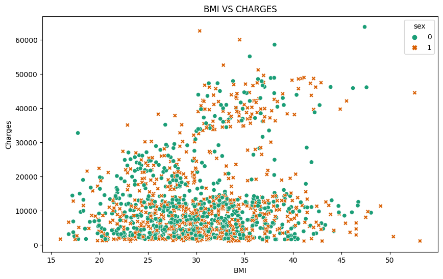

```python
plt.figure(figsize=(10,6))
sns.scatterplot(x=df["bmi"],y=df["charges"],hue=df["sex"],style=df["sex"],palette="Dark2")
plt.xlabel("BMI")
plt.ylabel("Charges")
plt.title("BMI VS CHARGES")
plt.show()
```

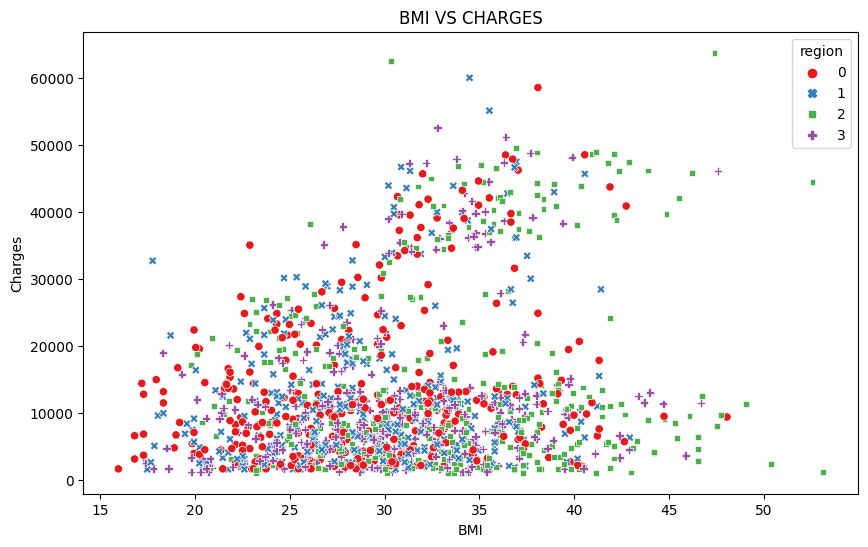

```python
plt.figure(figsize=(10,6))
sns.scatterplot(x=df["bmi"],y=df["charges"],hue=df["region"],style=df["region"],palette="Set1")
plt.xlabel("BMI")
plt.ylabel("Charges")
plt.title("BMI VS CHARGES")
plt.show()
```

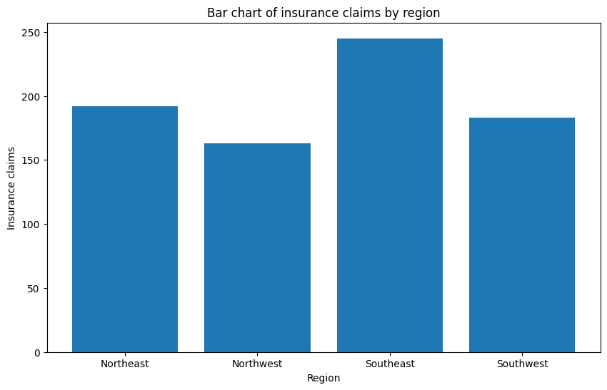

```python
plt.figure(figsize=(10,6))
claims_by_region = df.groupby('region')['insuranceclaim'].sum()
plt.bar(claims_by_region.index, claims_by_region.values)
plt.xticks(range(4), ['Northeast', 'Northwest', 'Southeast', 'Southwest'])
plt.xlabel('Region')
plt.ylabel('Insurance claims')
plt.title('Bar chart of insurance claims by region')
plt.show()
```

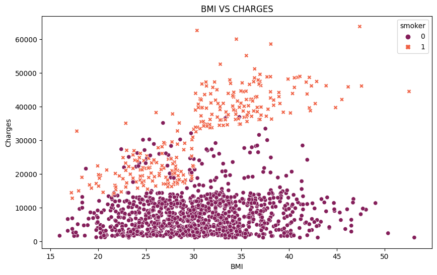

```python
plt.figure(figsize=(10,6))
sns.scatterplot(x=df["bmi"],y=df["charges"],hue=df["smoker"],style=df["smoker"],palette="rocket")
plt.xlabel("BMI")
plt.ylabel("Charges")
plt.title("BMI VS CHARGES")
plt.show()
```

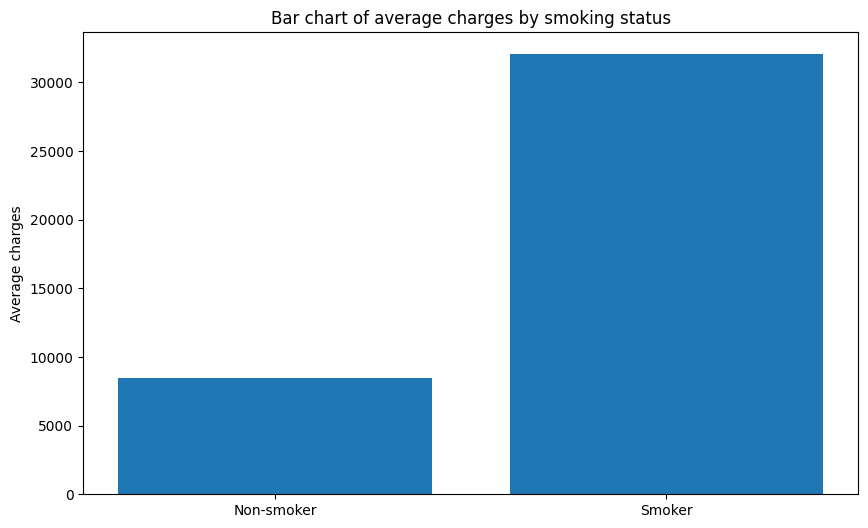

```python
plt.figure(figsize=(10,6))
smoker_charges = df.groupby('smoker')['charges'].mean()
plt.bar(['Non-smoker', 'Smoker'], smoker_charges)
plt.ylabel('Average charges')
plt.title('Bar chart of average charges by smoking status')
plt.show()
```

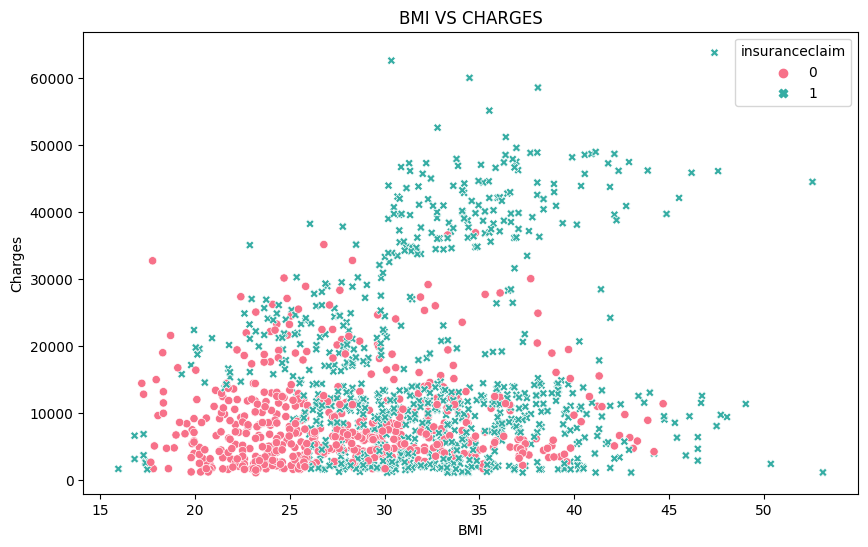

```python
plt.figure(figsize=(10,6))
sns.scatterplot(x=df["bmi"],y=df["charges"],hue=df["insuranceclaim"],style=df["insuranceclaim"],palette="husl")
plt.xlabel("BMI")
plt.ylabel("Charges")
plt.title("BMI VS CHARGES")
plt.show()
```

BMI v/s Claim

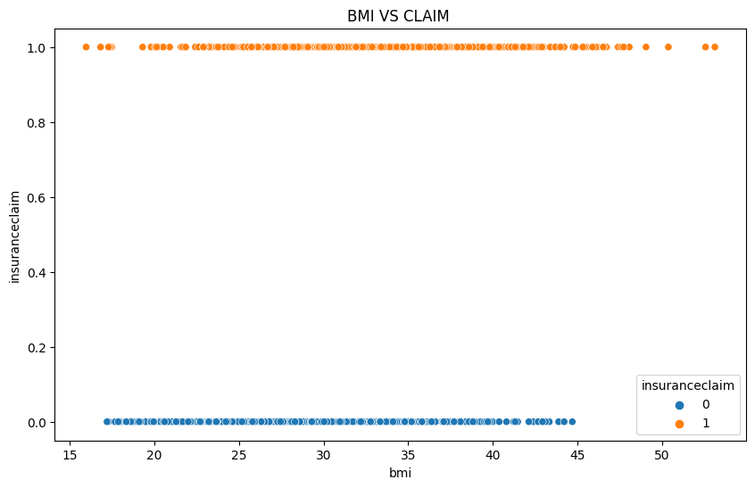

```python
plt.figure(figsize=(10,6))
sns.scatterplot(x=df["bmi"],y=df["insuranceclaim"],hue=df["insuranceclaim"])
plt.title("BMI VS CLAIM ")
plt.show()
```

#### Observations:

1.BMI is **Normally Distributed**.

2.We were trying to find any sort of relationship between BMI and AGE but plotting it did not show any sort of relationship.

4.For scatter plot of **Charges and Bmi** sex and region don't play any role.

5.Smokers have high isurance charges and non-smokers have low insurance charges.

7.People ranging of all BMI's have made a claim.

8.Highest Insurance claims are made by Individuals of Southeast Region.

Plot for Age

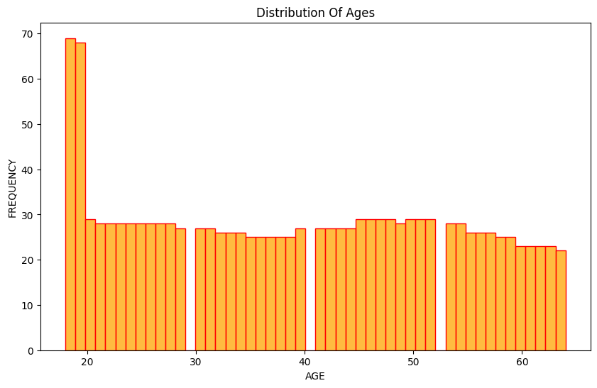

```python
plt.figure(figsize=(10,6))
sns.histplot(df["age"],color="orange",bins=50,edgecolor="red")
plt.xlabel("AGE")
plt.ylabel("FREQUENCY")
plt.title("Distribution Of Ages")
plt.show()
```

Age v/s Charges

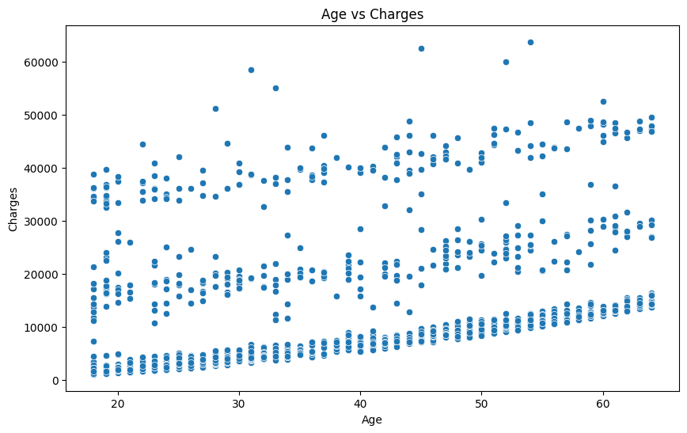

```python
plt.figure(figsize=(10,6))
sns.scatterplot(x=df["age"],y=df["charges"])
plt.xlabel('Age')
plt.ylabel('Charges')
plt.title('Age vs Charges')
plt.show()
```

Age v/s Childrens

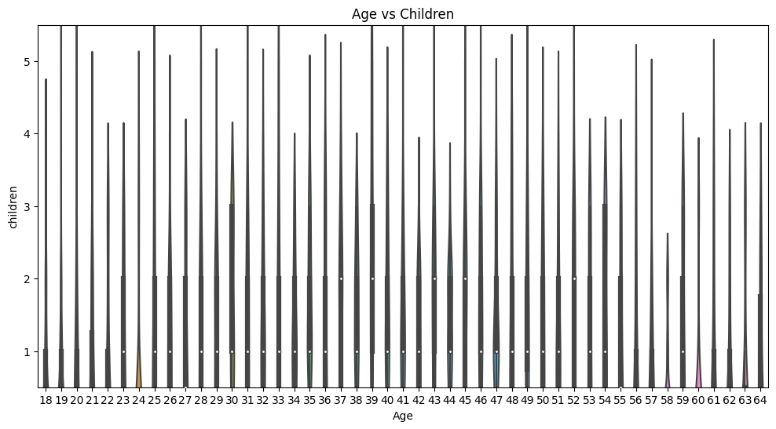

```python
fig, ax = plt.subplots(figsize=(12, 6))
sns.violinplot(x=df["age"],y=df["children"])
ax.set_ylim(bottom=0.5, top=df['children'].max()+0.5)
plt.xlabel('Age')
plt.ylabel('children')
plt.title('Age vs Children')
plt.show()
```

Age vs Insurance Claim

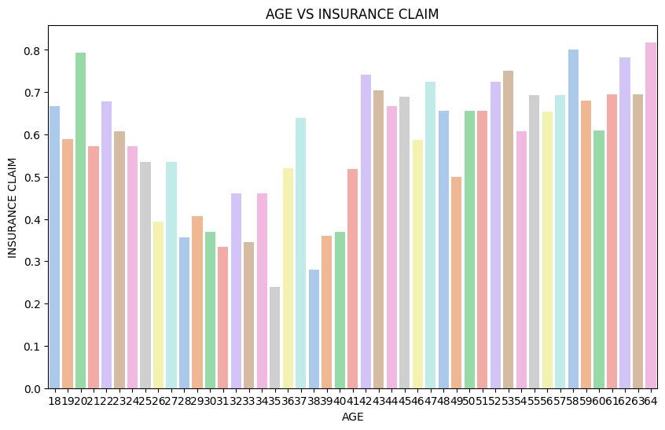

```python
plt.figure(figsize=(10,6))
sns.barplot(x=df["age"],y=df["insuranceclaim"], palette="pastel",ci=None)
plt.xlabel("AGE")
plt.ylabel("INSURANCE CLAIM")
plt.title("AGE VS INSURANCE CLAIM")
plt.show()
```

Plotting For Smoker and age

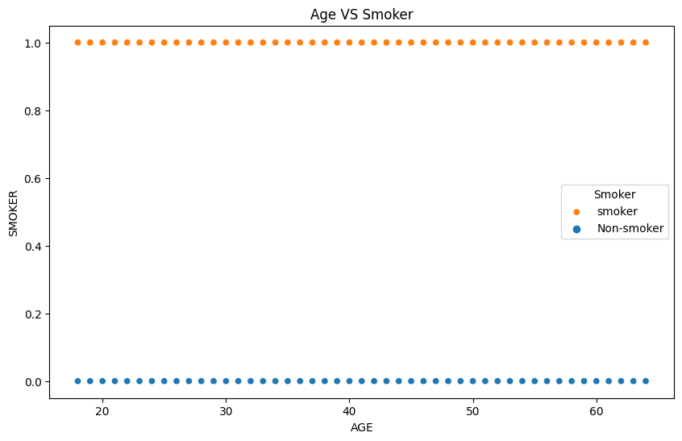

```python
plt.figure(figsize=(10,6))
sns.scatterplot(x=df["age"],y=df["smoker"],hue=df["smoker"])
plt.xlabel("AGE")
plt.ylabel("SMOKER")
plt.title("Age VS Smoker")
plt.legend(title="Smoker", labels=["smoker", "Non-smoker"])
plt.show()
```

Plotting for Smoker and charges

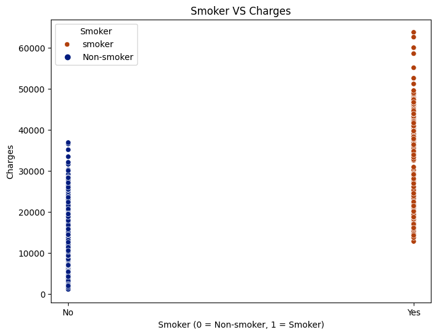

```python
plt.figure(figsize=(8,6))
sns.scatterplot(x=df["smoker"],y=df["charges"],hue=df["smoker"],palette="dark")
plt.xlabel("Smoker (0 = Non-smoker, 1 = Smoker)")
plt.ylabel("Charges")
plt.title("Smoker VS Charges")
plt.xticks(ticks=[0,1], labels=["No", "Yes"])
plt.legend(title="Smoker", labels=["smoker", "Non-smoker"])
plt.show()
```

Plotting for Charges v/s Claim

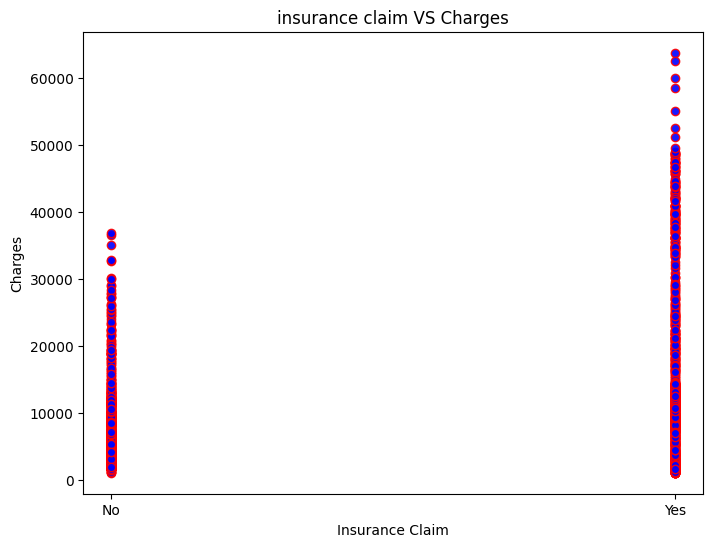

```python
plt.figure(figsize=(8,6))
plt.scatter(x=df["insuranceclaim"],y=df["charges"],color="blue",edgecolors="red",alpha=0.9)
plt.xlabel("Insurance Claim")
plt.ylabel("Charges")
plt.xticks(ticks=[0,1], labels=["No", "Yes"])
plt.title("insurance claim VS Charges")
plt.show()
```

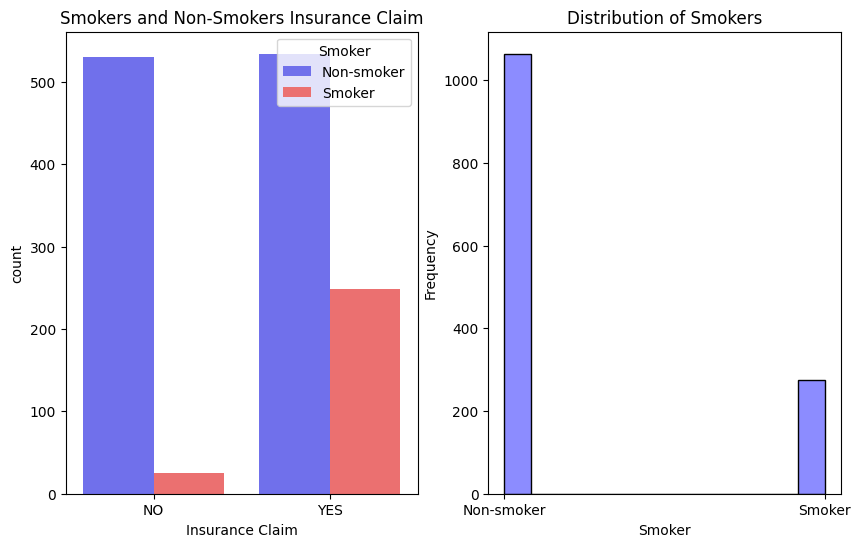

```python
fig, axs = plt.subplots(1, 2, figsize=(10,6))

# subplot for the countplot
sns.countplot(x=df["insuranceclaim"], hue=df["smoker"], palette=["#5C5CFF", "#FF5C5C"], ax=axs[0])
axs[0].set_xlabel("Insurance Claim")
axs[0].legend(title="Smoker", labels=["Non-smoker", "Smoker"])
axs[0].set_xticks([0,1])
axs[0].set_xticklabels(["NO","YES"])
axs[0].set_title("Smokers and Non-Smokers Insurance Claim")

# subplot for the histogram
sns.histplot(x=df['smoker'], ax=axs[1], color='#5C5CFF', alpha=0.7)
axs[1].set_xlabel('Smoker')
axs[1].set_ylabel('Frequency')
axs[1].set_title('Distribution of Smokers')
axs[1].set_xticks([0,1])
axs[1].set_xticklabels(["Non-smoker","Smoker"])
plt.show()
```

plotting for claim made vs region

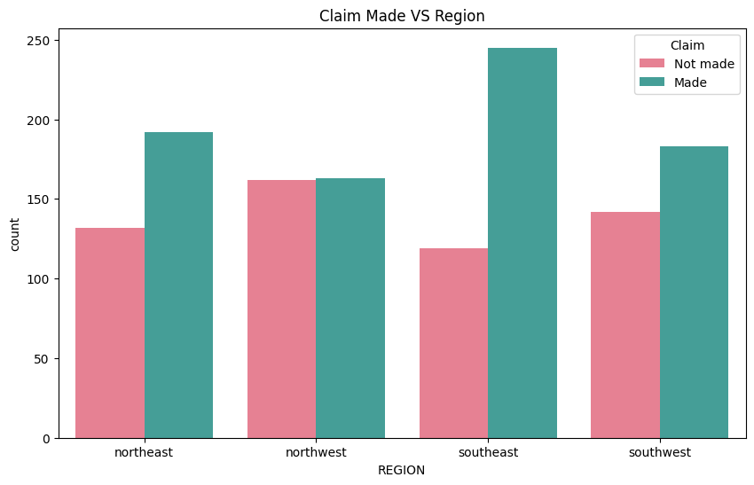

```python
plt.figure(figsize=(10,6))
sns.countplot(x=df["region"],hue=df["insuranceclaim"],palette="husl")
plt.xlabel("REGION")
plt.legend(title="Claim",labels=['Not made', 'Made'])
plt.title("Claim Made VS Region")
regions=['northeast', 'northwest', 'southeast', 'southwest']
plt.xticks(ticks=[0,1,2,3],labels=regions)
plt.show()
```

plotting for children vs charges

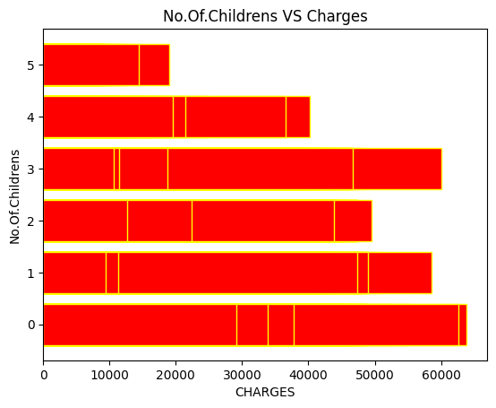

```python
plt.barh(df["children"],df["charges"],color="red",edgecolor="yellow")
plt.xlabel("CHARGES")
plt.ylabel("No.Of.Childrens")
plt.title("No.Of.Childrens VS Charges")
plt.show()
```

Claims by Smokers

[figure not shown]

```python
plt.figure(figsize=(10,6))
claims_by_smoker = df.groupby('smoker')['insuranceclaim'].value_counts()
plt.pie(claims_by_smoker, labels=['Non-smoker/No claim', 'Smoker/No claim', 'Non-smoker/Claim', 'Smoker/Claim'], autopct='%1.1f%%')
plt.title('Pie chart of insurance claims by smoker status')
plt.show()
```

Line plot Age v/s Charges

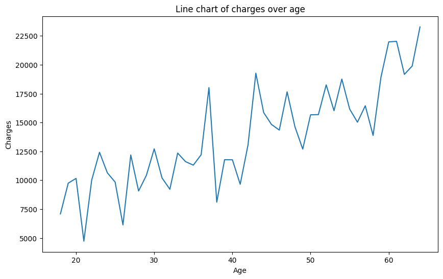

```python
plt.figure(figsize=(10,6))
charges_by_age = df.groupby('age')['charges'].mean()
plt.plot(charges_by_age.index, charges_by_age.values)
plt.xlabel('Age')
plt.ylabel('Charges')
plt.title('Line chart of charges over age')
plt.show()
```

#### Observations:

1.Constant no.of people are buying insurance after year of 20 age but no.of people buying insurance from 18-20 are more in comparision to others.Its more than 2X than people of other ages.

2.There are some people who are starting with less amount of charges and increasing with time,linear relationship can be seen between them.But no pattern can be seen between some people as they are starting with more charges when age is less.

3.All sort of people ranging from/starting with 18 are having childrens.

4.There are bunch of people from all ages as Smokers i.e.Not some age group people are only smokers.

5.People who are smoker are having high charges.

6.There are more no.of Non-Smokers in dataset,but we also plotted that those who are smokers they have made more claim for insurance.

7.Claims are made from each region but from southeast region claims made are much higher in terms of claim not made.

8.No pattern found In no.of Children VS charges paid.

9.With increasing age Insurance charges increases.

### Correlations:

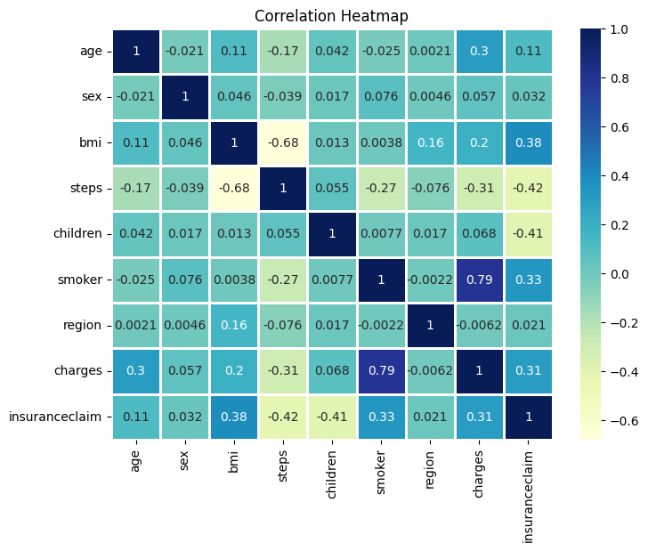

```python
plt.figure(figsize=(8,6))
sns.heatmap(df.corr(),annot=True,cmap="YlGnBu", linewidths=0.9)
plt.title("Correlation Heatmap")
plt.show()
```

### Observations:

1.Childrens and claim is **negatively correlated**.

2.**BMI** is Correlated with **Claim**.

### **Conclusions From EDA:**

1.A large number of people at the age of 18-19 have purchased an insurance policy compared to other age groups.

2.There is a sudden drop in the number of purchases among individuals above the age of 19.

3.This could be due to specific marketing or promotional campaigns targeting this particular age group.

4.It may be worth further investigating data points such as an **individual at the age of 18 having 4 kids** to ensure accuracy and representative of the rest of the data.

### Observations:

1.There are outliers in **smoker** and **charges**.

##### But we are not going to drop outliers as there is corelation between these features and target.

# Check For Outliers:

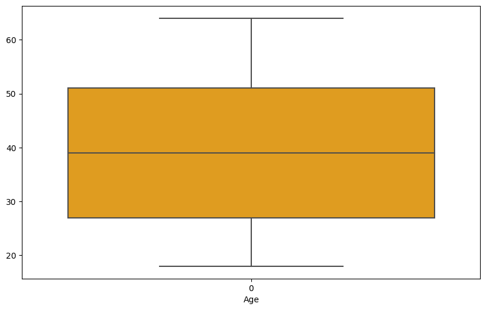

```python
#age
plt.figure(figsize=(10, 6))
sns.boxplot(df["age"],color="orange")
plt.xlabel("Age")
plt.show()
```

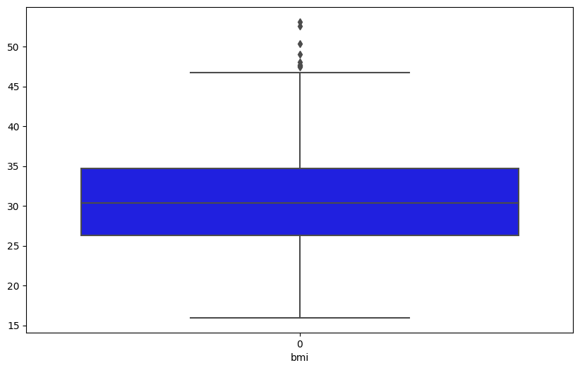

```python
#bmi
plt.figure(figsize=(10,6))
sns.boxplot(df["bmi"],color="blue")
plt.xlabel("bmi")
plt.show()
```

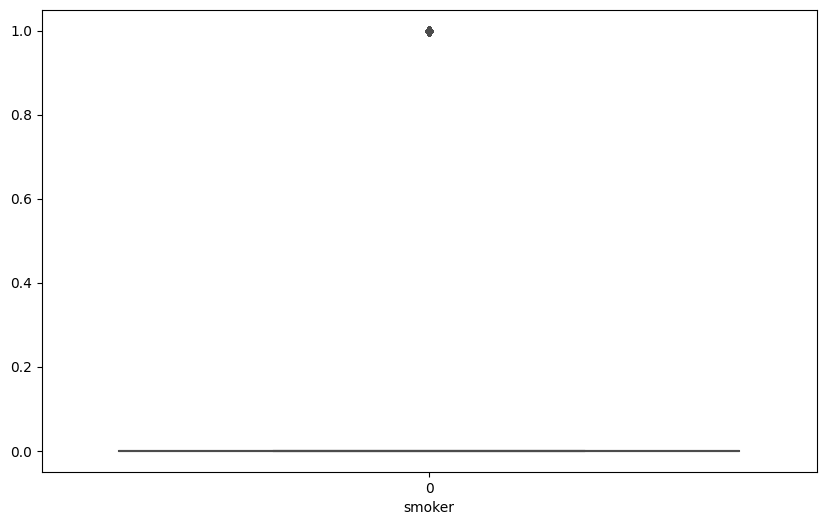

```python
#smoker
plt.figure(figsize=(10,6))
sns.boxplot(df["smoker"],color="blue")
plt.xlabel("smoker")
plt.show()
```

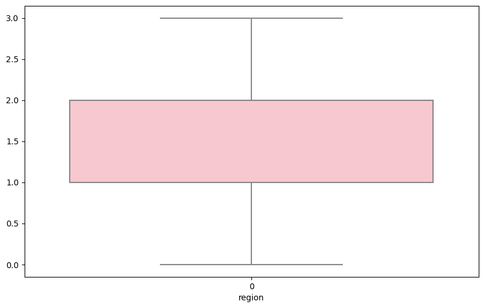

```python
#smoker
plt.figure(figsize=(10,6))
sns.boxplot(df["region"],color="pink")
plt.xlabel("region")
plt.show()
```

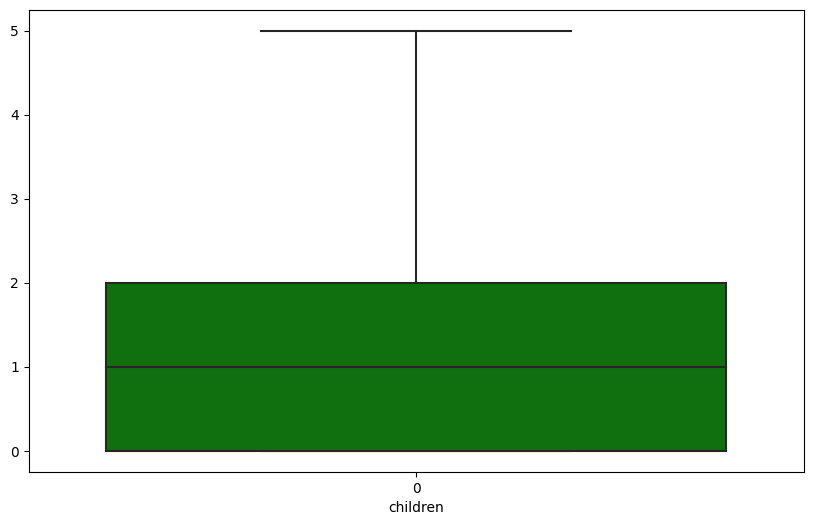

```python
#smoker
plt.figure(figsize=(10,6))
sns.boxplot(df["children"],color="green")
plt.xlabel("children")
plt.show()
```

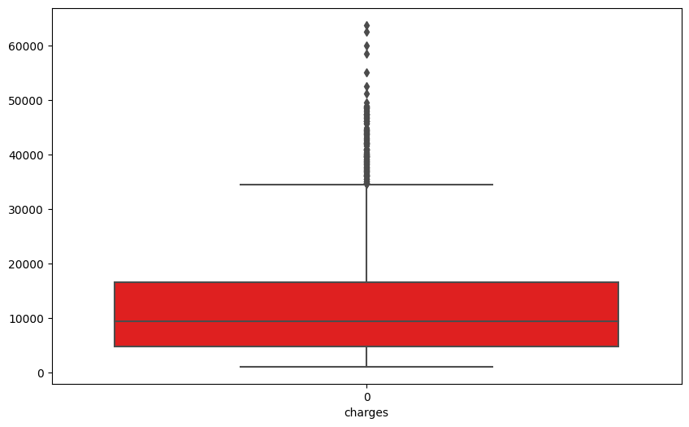

```python
#charges
plt.figure(figsize=(10,6))
sns.boxplot(df["charges"],color="red")
plt.xlabel("charges")
plt.show()
```